# Lunch & Learn - Python Automation

### Outlook - Display or Send Email

```python
import win32com.client as win32

outlook = win32.Dispatch('outlook.application') #open outlook
mail = outlook.CreateItem(0) #create new mail
mail.To = 'm.karlsson@nordea.com'
mail.Cc = 'PC GR Curves'
mail.Subject = 'Equity T+1'
mail.HTMLBody = 'Hello Martin'
mail.display()
```

[figure not shown]

```python
Image(filename='C:\Users\G53283\Desktop\Lunch & Learn\Email example.png')
```

```python
outlook = win32.Dispatch('outlook.application')
mail = outlook.CreateItem(0)
mail.To = 'm.karlsson@nordea.com'
mail.Cc = 'PC GR Curves'
mail.Subject = 'Equity T+1 '+Yesterday_B
mail.HTMLBody = """\
<html>
  <head></head>
  <body>
    <p>Hi,<br>
    <br>
       The following equities breached the EUR 50,000 threshold in terms of IPV variance:<br>
       <br>
    </p>
  </body>
</html>
"""
mail.HTMLBody += df.to_html(na_rep = "", index = False).replace('<th>','<th style = "background-color: navy; font-size:10pt;">').replace('<tbody>', '<tbody style = "font-size:10pt; text-align: center;">')
mail.display()
```

[figure not shown]

```python
Image(filename='C:\Users\G53283\Desktop\Lunch & Learn\Email example 2.png')
```

Mail with Attachments

```python
import win32com.client

outlook = win32.Dispatch('outlook.application')
mail = outlook.CreateItem(0)
mail.To = ''
mail.Cc = ''
mail.Subject = ''
mail.HTMLBody = """"""

attachment1 = "Path to attachment no. 1"
attachment2 = "Path to attachment no. 2"

mail.Attachments.Add(attachment1)
mail.Attachments.Add(attachment2)

mail.display()
#mail.send()
```

Create a function

```python
import win32com.client as win32

def Emailer(To, subject, message):

    outlook = win32.Dispatch('outlook.application')

    mail = outlook.CreateItem(0)
    mail.To = To
    mail.Subject = subject
    mail.GetInspector

    index = mail.HTMLbody.find('>', mail.HTMLbody.find('<body'))
    mail.HTMLbody = mail.HTMLbody[:index + 1] + message + mail.HTMLbody[index + 1:]

mail.Display(True)
```

```python
Emailer("david@bisnode.com","Subject","Hi there", )
```

```python
from IPython.display import FileLink

FileLink("Untitled9.ipynb")
```

Untitled9.ipynb

### The OS library

Check your current directory

```python
import os

os.getcwd()
```

```
'/Users/aleksanderedemann'
```

If most of your files are located somewhere else you can change the directory

```python
os.chdir('/Users/aleksanderedemann/Documents')

os.getcwd()
```

```
'/Users/aleksanderedemann/Documents'
```

Use listdir to see all the files you have in that directory

```python
os.listdir()
```

```
['.DS_Store',
 '.localized',
 '.parallels-vm-directory',
 'Automation',
 'Digital Editions',
 'L&L (WIP).ipynb',
 'Microsoft User Data',
 'Microsoft_Office_2011',
 'Nordea',
 'Parallels',
 'Python.txt',
 'RDC Connections',
 'Research']
```

```python
os.rename('Python.txt','Loveit.txt')
```

```python
os.listdir()
```

```
['.DS_Store',
 '.localized',
 '.parallels-vm-directory',
 'Automation',
 'Digital Editions',
 'L&L (WIP).ipynb',
 'Loveit.txt',
 'Microsoft User Data',
 'Microsoft_Office_2011',
 'Nordea',
 'Parallels',
 'RDC Connections',
 'Research']
```

## Jupyter's Magic

Run a myriad of small (and often very fast) programs in a series with Bash

Open a file with bash

```python
%%bash

open Documents/Loveit.txt
```

Search for something in the folders you want

```python
%%bash

grep -wnr "Hello Python" Documents
```

[output not shown]

Copy the content from the file into Jupyter

```python
%%bash

cat Documents/Loveit.txt
```

```
Hello Python
```

Use %qtconsole to execute code against the current kernel without modifying the notebook document

```python
%qtconsole

a = 2
b = 3
```

Debugging

```python
%pdb
```

```
Automatic pdb calling has been turned ON
```

```python
h0 = 1
h1 = 2
h3 = h4
```

Execute other notebooks without opening them. Note only works with py extensions

```python
%run trailrun.py
```

```
The installed widget Javascript is the wrong version.
```

```
SQL is Running
```

Load in code from other notebooks

```python
%load trailrun.py
```

```python
x = str(1)
y = str(2)
z = str(3)

%who
```

```
Accordion	 BoundedFloatText	 BoundedIntText	 Box	 Button	 CallbackDispatcher	 Checkbox	 Color	 ColorPicker
Controller	 DOMWidget	 Dropdown	 EventfulDict	 EventfulList	 FlexBox	 FloatProgress	 FloatRangeSlider	 FloatSlider
FloatText	 HBox	 HTML	 Image	 IntProgress	 IntRangeSlider	 IntSlider	 IntText	 Label
Latex	 Layout	 Output	 PlaceProxy	 Proxy	 RadioButtons	 Select	 SelectMultiple	 SelectionSlider
Tab	 Text	 Textarea	 ToggleButton	 ToggleButtons	 VBox	 Valid	 Widget	 button
display	 dlink	 domwidget	 eventful	 f	 find_static_assets	 fixed	 get_ipython	 handle_kernel
handle_version_comm_opened	 ifclicked	 interact	 interact_manual	 interaction	 interactive	 jsdlink	 jslink	 load_ipython_extension
os	 register	 register_comm_target	 trait_types	 version_info	 widget	 widget_bool	 widget_box	 widget_button
widget_color	 widget_controller	 widget_float	 widget_image	 widget_int	 widget_layout	 widget_link	 widget_output	 widget_selection
widget_selectioncontainer	 widget_serialization	 widget_string	 widgets	 x	 y	 z
```

Time your loops with %%time

```python
%%time

for i in range(0,10000):
    b = i
```

```
CPU times: user 996 µs, sys: 0 ns, total: 996 µs
Wall time: 1 ms
```

Multi cursor in Jupyter - very handy for SQL scripts. Press the Alt button and keep holding it. The cursor should change its shape into a big plus sign. The next step is, using your mouse, to point to the beginning of the first line you want to comment and while holding the Alt button pull down your mouse until the last line you want to comment. Finally, you can release the Alt button and start typing.

Alt + mouse selection for multiline selection and Ctrl + mouse clicks for multicursors.

[figure not shown]

Hide all code in a notebook

```python
from IPython.display import display
from IPython.display import HTML
import IPython.core.display as di

# This line will hide code by default when the notebook is exported as HTML
di.display_html('<script>jQuery(function() {if (jQuery("body.notebook_app").length == 0) { jQuery(".input_area").toggle(); jQuery(".prompt").toggle();}});</script>', raw=True)

# This line will add a button to toggle visibility of code blocks, for use with the HTML export version
di.display_html('''<button onclick="jQuery('.input_area').toggle(); jQuery('.prompt').toggle();">Toggle code</button>''', raw=True)
```

# Appendix

#### Use !pip list to check all the packages you've installed

```python
!pip list
```

[output not shown]

[output cut: 272 more lines]

[output not shown]

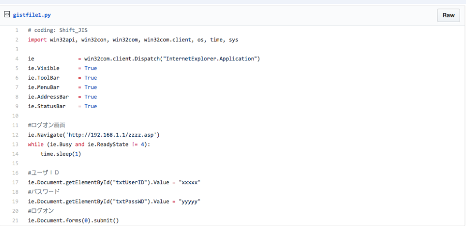

```python
Image(filename=r'C:\Users\G53283\Desktop\Lunch & Learn\scrape.png')
```

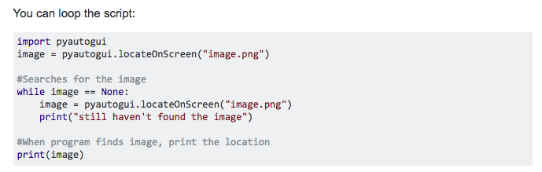

```python
Image(filename=r'C:\Users\G53283\Desktop\Lunch & Learn\pyauto.png')
```

```python
!conda info --envs
```

```
# conda environments:
#
base                  *  /Users/aleksanderedemann/anaconda
Py27                     /Users/aleksanderedemann/anaconda/envs/Py27
tensorflow               /Users/aleksanderedemann/anaconda/envs/tensorflow
```

```python
!conda env list
```

```
# conda environments:
#
base                  *  /Users/aleksanderedemann/anaconda
Py27                     /Users/aleksanderedemann/anaconda/envs/Py27
tensorflow               /Users/aleksanderedemann/anaconda/envs/tensorflow
```

Pandas Cheatsheet

[figure not shown]

Numpy Cheatsheet

[figure not shown]

Win32com Excel notes

```python
import win32com.client
xlApp = win32com.client.Dispatch("Excel.Application")

#Open Excel file.
wb = xlApp.Workbooks.Open("")

#Close the Excel file.
wb.Close()

#Save the Excel file.
wb.Save()

# Save as
wb.SaveAs("")

#Display Excel.
xlApp.Visible = 1

#Make the designated sheet operable.
ws = wb.Worksheets("Sheet1")

#Place the specified sheet in selected state.
ws.Activate()
# OR
ws.Select()
# OR
wb.Worksheets("Sheet1").Activate()

#Select Range
ws.Range("A1:A5").Select()
ws.Range("A4").Value = ""
ws.Range("E:G").Delete()
ws.Range("E1:E8").Delete(Shift = -4159)
ws.Range("1:3").Copy()
ws.Range("10:10").Insert()
ws.Range("E3").Activate()
ws.Paste()
ws.UsedRange()

#Formatting Range
ws.Range("A1").Borders(7).LineStyle = 1
ws.Range("A1").Borders(7).Weight = 2
ws.Range("A1").Borders(7).ColorIndex = -4105
ws.Range("A1").Borders(7).LineStyle = None

#Columns and Rows
ws.Columns('A:B').Select()
ws.Rows('1:2').Select()

ws.Rows("1:1").RowHeight = 25
ws.Columns("A:A").ColumnWidth = 15
```

```python
!jupyter nbconvert LL.ipynb
```

```
[NbConvertApp] Converting notebook LL.ipynb to html
[NbConvertApp] Writing 1779546 bytes to LL.html
```

```python
!jupyter nbconvert --to slides LL.ipynb
```

```
[NbConvertApp] Converting notebook LL.ipynb to slides
[NbConvertApp] Writing 1770828 bytes to LL.slides.html
```

```python
!jupyter nbconvert --to pdf LL.ipynb
```

[output not shown]